# Reproducible Research Project 1

Kintak Raymond Yu

26/08/2020

## Overview

This document summaries the exploratory data analysis of data collected from a personal activity monitoring device. The device records the number of steps taken in 5 minute intervals each day for an anonymous individual during October and November, 2012.

## Loading and preprocessing the data

```r
# Read in the data
library(tidyverse)
df <- read_csv("../Data/activity.csv", col_names = TRUE)
summary(df)
```

```
##      steps             date               interval
##  Min.   :  0.00   Min.   :2012-10-01   Min.   :   0.0
##  1st Qu.:  0.00   1st Qu.:2012-10-16   1st Qu.: 588.8
##  Median :  0.00   Median :2012-10-31   Median :1177.5
##  Mean   : 37.38   Mean   :2012-10-31   Mean   :1177.5
##  3rd Qu.: 12.00   3rd Qu.:2012-11-15   3rd Qu.:1766.2
##  Max.   :806.00   Max.   :2012-11-30   Max.   :2355.0
##  NA's   :2304
```

```r
str(df)
```

```
## tibble [17,568 x 3] (S3: spec_tbl_df/tbl_df/tbl/data.frame)
##  $ steps   : num [1:17568] NA NA NA NA NA NA NA NA NA NA ...
##  $ date    : Date[1:17568], format: "2012-10-01" "2012-10-01" ...
##  $ interval: num [1:17568] 0 5 10 15 20 25 30 35 40 45 ...
##  - attr(*, "spec")=
##   .. cols(
##   ..   steps = col_double(),
##   ..   date = col_date(format = ""),
##   ..   interval = col_double()
##   .. )
```

## Number of steps taken each day

First, Let’s find out how many steps are taken each day?

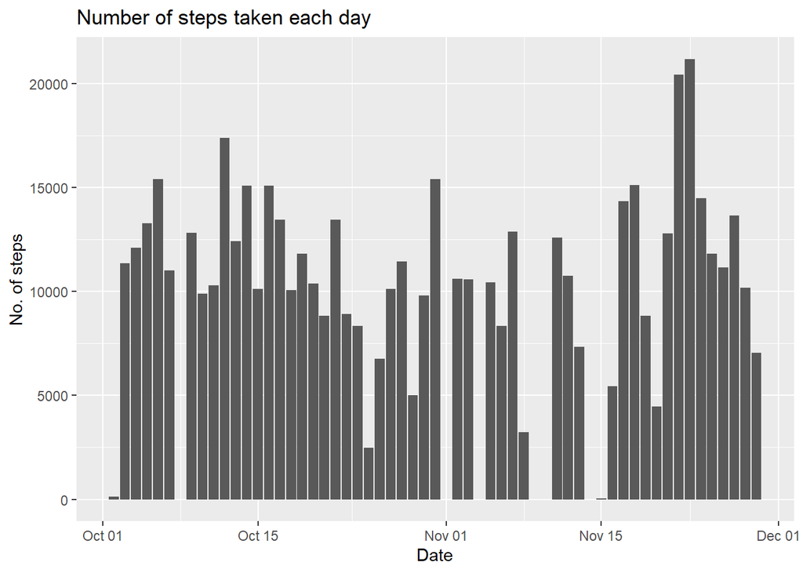

```r
# How many steps are taken each day?
library(tidyverse)
dd <- df %>% group_by(date) %>% summarise(counts= sum(steps))

library(ggplot2)
Pdf <- ggplot(data = dd, aes(x = date, y = counts)) +
  geom_col() +
  labs(title="Number of steps taken each day", x = "Date", y="No. of steps")
Pdf
```

The number of steps looks rather even across the time frame. What is the mean and median of the total number of steps taken per day?

It was mentioned that there is **NA** in the data. Let’s see how they are like first.

```r
library(tidyverse)
# Check NA
dfNA <- df %>% filter(is.na(steps)) %>% group_by(date) %>% summarise(`counts of NA` = n())

# list the counts
dfNA$`counts of NA`
```

```
## [1] 288 288 288 288 288 288 288 288
```

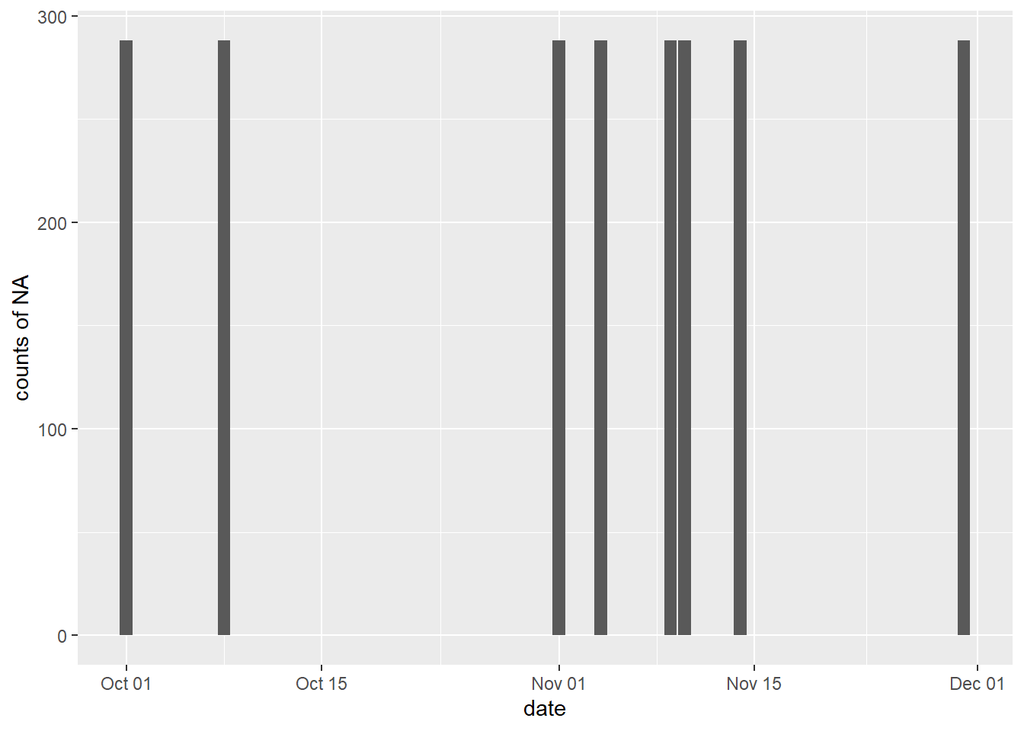

```r
# graph the distribution over the days
library(ggplot2)
PNA <- ggplot(data = dfNA, aes(x = date, y = `counts of NA`)) +
  geom_col()
PNA
```

```r
# simple counts
nNADay <- dfNA %>% summarise(n=n())
nNATot <- sum(dfNA$`counts of NA`)
```

In the data set, there are 2304 **NA** records, evenly spread across 8 days.

Since, 12 $\times$ 24 = 288, so whenever there are **NA** records in day, the data for that whole day will be missing.

Let’s compute the mean in 2 ways:

1. average the total number of steps over all the days,
2. average over only those days that does not have **NA**.

On the other hand, since the **NA** results will not alter the median. No such consideration is made.

```r
nDay <- dd %>% summarise(n())

# mean, counting all the days
nStepsMeanAllDays   <- dd %>% summarise(sum(counts, na.rm=TRUE))/nDay
nStepsMeanAllDays
```

```
##   sum(counts, na.rm = TRUE)
## 1                   9354.23
```

```r
# mean, counting only the no NA days
nStepsMeanNoNADays <- dd %>% summarise(mean(counts, na.rm=TRUE))
nStepsMeanNoNADays
```

```
## # A tibble: 1 x 1
##   `mean(counts, na.rm = TRUE)`
##                          <dbl>
## 1                       10766.
```

```r
# median
nStepsMedianNoNADays <- dd %>% summarise(median(counts, na.rm=TRUE))
nStepsMedianNoNADays
```

```
## # A tibble: 1 x 1
##   `median(counts, na.rm = TRUE)`
##                            <dbl>
## 1                          10765
```

Naturally, the mean values counting all the days is smaller than that only counting the no **NA** days are different.

The mean (ignoring the days with **NA**) and the median are actually very close.

## Average daily activity pattern

Here, the average daily activity pattern is examined.

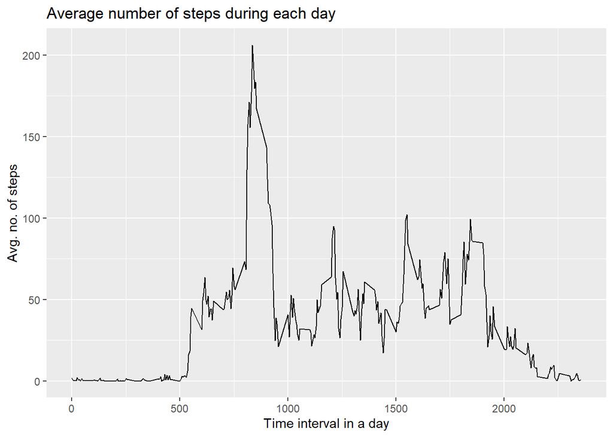

```r
# prep the data to get the daily average of steps
dfAvg <- df %>% group_by(interval) %>% summarise(mean = mean(steps, na.rm=TRUE))
library(ggplot2)
PAvg <- ggplot(data = dfAvg, aes(interval, mean)) +
  geom_line() +
  labs(title="Average number of steps during each day", x = "Time interval in a day", y="Avg. no. of steps")
PAvg
```

```r
# get the index of the max interval
im <- which.max(dfAvg$mean)
```

The internal that has the max value is the 104$^{th}$ internal, which corresponds to the interval value of 835.

```r
# check the pattern of the interval to see what it means ...
head(df$interval,36)
```

```
##  [1]   0   5  10  15  20  25  30  35  40  45  50  55 100 105 110 115 120 125 130
## [20] 135 140 145 150 155 200 205 210 215 220 225 230 235 240 245 250 255
```

Looking at the pattern in the time interval, 835 should mean 8:35 am.

## About missing values

Recall from above that there are 2304 **NA** records, evenly spread across 8 days. In particular, when there is **NA** in a day, the data for that whole day will be missing.

Let’s impute the missing values with the average number of steps for that 5 minute interval obtained above. In other words, the day with **NA** is set to be the same as the averaged day pattern.

```r
# create the new dff with the NA interval filled with the mean of that interval
dff <- df
dff <- dff %>% mutate (steps = ifelse(date %in% dfNA$date, dfAvg$mean, steps))
```

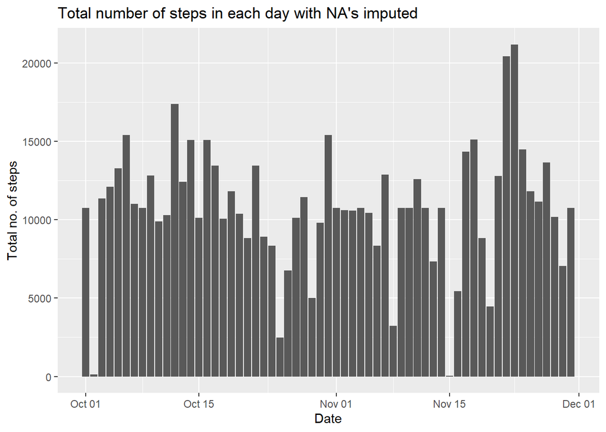

```r
# prep the data to get the total number of daily steps again
dfTot <- dff %>% group_by(date) %>% summarise(total = sum(steps))
library(ggplot2)
Pdff <- ggplot(data = dfTot, aes(date, total)) +
  geom_col() +
  labs(title="Total number of steps in each day with NA's imputed", x = "Date", y="Total no. of steps")
Pdff
```

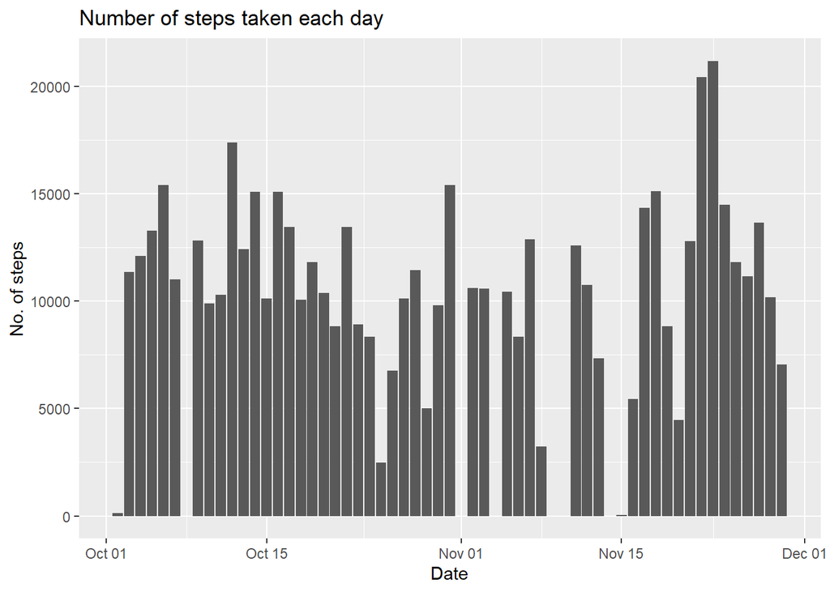

```r
# compare with the originally again
Pdf
```

```r
# get the new mean and median
ddnew <- dff %>% group_by(date) %>% summarise(counts= sum(steps))
nStepsMeanNew <- ddnew %>% summarise(mean(counts))
nStepsMeanNew
```

```
## # A tibble: 1 x 1
##   `mean(counts)`
##            <dbl>
## 1         10766.
```

```r
nStepsMedianNew <- ddnew %>% summarise(median(counts))
nStepsMedianNew
```

```
## # A tibble: 1 x 1
##   `median(counts)`
##              <dbl>
## 1           10766.
```

Comparing this with the previous results, the new Mean is close to the mean when **NA** in the data are ignored using **na.rm**. But it is very much different from the one computed by dividing the total steps over the total number of days (which is only 9354.23).

As for the median, it is very slightly increased by the data imputing.

## Activity patterns between weekdays and weekends

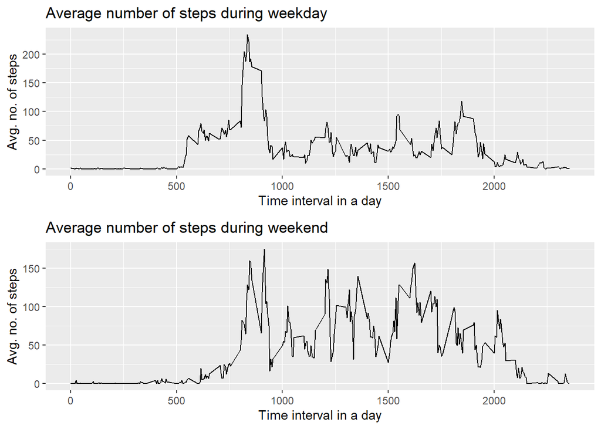

```r
# add a two-level factor for weekdays and weekend
library(tidyverse)
df$days <- as.factor(weekdays(df$date))
df$day2 <- fct_collapse(df$days,
                        weekday = c('Monday', 'Tuesday', 'Wednesday', 'Thursday', 'Friday'),
                        weekend = c('Saturday', 'Sunday'))

# get the average step per intervals for weekday and weekend
dfAvgWeekday <- df %>% filter(day2=='weekday') %>%
  group_by(interval) %>%
  summarise(mean = mean(steps, na.rm=TRUE))

dfAvgWeekend <- df %>% filter(day2=='weekend') %>%
  group_by(interval) %>%
  summarise(mean = mean(steps, na.rm=TRUE))

# prepare plots to compare the pattern
library(ggplot2)
library(ggpubr)
pweekday <- ggplot(data = dfAvgWeekday, aes(interval, mean)) +
  geom_line() +
  labs(title="Average number of steps during weekday", x = "Time interval in a day", y="Avg. no. of steps")


pweekend <- ggplot(data = dfAvgWeekend, aes(interval, mean)) +
  geom_line() +
  labs(title="Average number of steps during weekend", x = "Time interval in a day", y="Avg. no. of steps")

figure <- ggarrange(pweekday, pweekend, ncol = 1, nrow = 2)
figure
```

It is clear that during the weekend, the subject is more active during the day.